# Tutorial: Mechanistic Interpretability of Neural Networks

## Visualizing How AI "Thinks" in Geometry and Waves

**Objective:** In this tutorial, we will peer inside the "black box" of a neural network. We will train a single AI to perform two distinct mathematical tasks simultaneously: **Addition** (Linear) and **Modulo Division** (Non-Linear).

We will then use advanced forensic tools to answer: *How does the network organize its internal neurons to solve these contradictory problems without getting confused?*

**We will cover:**

1. **Geometric Projection (UMAP):** Seeing the "shape" of the math inside the brain.
2. **Spectral Analysis (Fourier):** Listening to the frequency of individual neurons.
3. **Bayesian Analysis:** Mapping where the AI is uncertain.

### 1. Setup and Reproducibility

First, we import our custom package `EXP_1`. We also define a `set_seed` function. Neural networks are initialized with random weights, which can lead to different results every time. Setting a seed ensures that your results match the explanations in this guide.

```python
import torch
import torch.nn as nn
import torch.optim as optim
import numpy as np
import random
import umap
import warnings

# Import our custom package modules

from data import TaskDataGenerator
from analyzer import NonLinearAnalyzer, FourierDetective, BayesianObserver, ManifoldAnalyzer
from model import ModuloNet
from viz import Visualizer

def set_seed(seed=42):
    """Sets the seed for reproducibility across all libraries."""
    torch.manual_seed(seed)
    torch.cuda.manual_seed_all(seed)
    np.random.seed(seed)
    random.seed(seed)
    torch.backends.cudnn.deterministic = True
    print(f"Random Seed set to {seed}")

# Apply the seed
set_seed(42)
```

```
Random Seed set to 42
```

### 2. The "Multi-Task" Experiment

We will ask the network to learn two functions based on a `task_id` input:

1. If `task_id` is 0: Calculate $x \% y$ (Modulo).
2. If `task_id` is 1: Calculate $x + y$ (Addition).

**Why is this hard?** Addition is a smooth, flat plane. Modulo is a jagged, sawtooth wave. The network must learn to fold space for one task while keeping it flat for the other, using the exact same neurons.

```python
# Configuration
TASK_MODE = "multi_task"
HIDDEN_LAYERS = 3
HIDDEN_DIM = 64
EPOCHS = 3000
LR_MAX = 0.01

# 1. Data Generation
print("Generating Multi-Task Data...")
input_dim = 3 if TASK_MODE == "multi_task" else 2
X_train, X_test, y_train, y_test = TaskDataGenerator.get_task_data(TASK_MODE, num_samples=2500)

# 2. Model Initialization
model = ModuloNet(input_dim=input_dim,
                  hidden_dim=HIDDEN_DIM,
                  output_dim=1,
                  num_hidden_layers=HIDDEN_LAYERS,
                  dropout_rate=0.1) # Dropout is required for Bayesian analysis later
```

```
Generating Multi-Task Data...
```

### 3. Training the "Black Box"

We use a standard training loop. Note the use of `OneCycleLR` scheduler—this starts with a low learning rate, ramps up to explore the geometry, and cools down to crystallize the best solution. We also capture snapshots of the model's "brain" (activations) at specific epochs to visualize the evolution later.

**Understanding the Plot:**

- **X-Axis (Epochs):** Represents time/iterations of training.
- **Y-Axis (RMSE Loss):** Represents the error. Lower is better.
- **Solid Lines:** The median error over a rolling window. Orange is Test (unseen data), Blue is Train.
- **Shaded Bands:** The "volatility" of learning. Wide bands mean the model is struggling to find a stable solution; narrow bands mean confident convergence.

```
Training for 3000 epochs...
Epoch 0: Test Loss (MSE) 0.23902
Epoch 500: Test Loss (MSE) 0.00299
Training Complete.
```

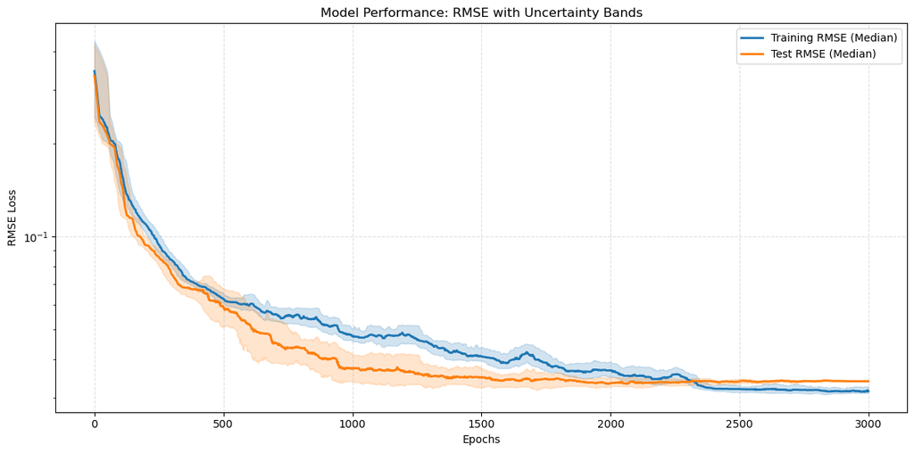

```python
optimizer = optim.Adam(model.parameters(), lr=LR_MAX)
scheduler = optim.lr_scheduler.OneCycleLR(optimizer, max_lr=LR_MAX,
                                          steps_per_epoch=1, epochs=EPOCHS)
criterion = nn.MSELoss()

train_losses = []
test_losses = []
raw_snapshots = []
capture_epochs = [0, 100, 500, EPOCHS-1]

print(f"Training for {EPOCHS} epochs...")

for epoch in range(EPOCHS):
    # Train Step
    model.train()
    optimizer.zero_grad()
    preds = model(X_train)
    loss = criterion(preds, y_train)
    loss.backward()
    optimizer.step()
    scheduler.step()

    # Evaluation Step
    model.eval()
    with torch.no_grad():
        test_preds = model(X_test)
        t_loss = criterion(test_preds, y_test)

    train_losses.append(loss.item())
    test_losses.append(t_loss.item())

    # Snapshot Logic
    if epoch in capture_epochs:
        with torch.no_grad():
            _, activations = model(X_test, return_activations=True)
            snapshot_layers = [act.detach().cpu().numpy() for act in activations]
            raw_snapshots.append(snapshot_layers)
        if epoch % 500 == 0:
             print(f"Epoch {epoch}: Test Loss (MSE) {t_loss.item():.5f}")

print("Training Complete.")

# Visualize Performance
Visualizer.plot_performance(train_losses, test_losses, window_size=100)
```